# Discrete Time Transmission Models in STAN

Arie Voorman

April 2017

## Simple SIR Model

Lets start with a simple SIR model. Suppose we observe whether someone is Susceptable (S), Infectious (I), or Recovered (R) for individuals $j=1 \dots n$ at times $t=1 \dots T$. Denote $S_t$, $I_t$, and $R_t$ as the set of individuals in each state at time $t$. We need models for the transmission of a person $S\rightarrow I$, and $I \rightarrow R$.

Now, for the transition $I\rightarrow R$, lets assume that mean shedding duration is $\gamma$ units of time, and that shedding duration follows a geometric distribution (i.e. the probability an individual stops shedding over 1-unit of time is $1/\gamma$)

### Simulation example

The code below simulates data from this model. After the simulation, I’ll write up a model in STAN that estimates the parameters $\lambda$ and $\gamma$ from observed data, and then use them to estimate $R_0$.

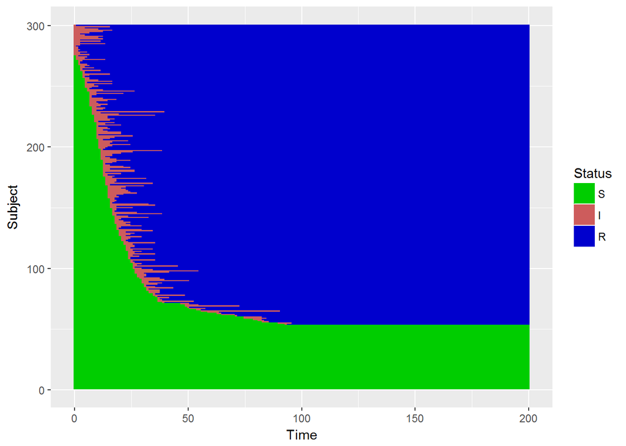

```r
##################### simulate data ###################
set.seed(42)
N = 300 # number of subjects
t = 200 # number of time points
lambda = 0.001 # transmission probability (per person per 'close contact', per day)
I0 = 25 # number of children initially infected
gamma = 7 # mean shedding duration for an individual

#data frame to store results
data = expand.grid(subject = 1:N, time = 0:t) %>%
  tbl_df()

#wdata is the 'wide' version of the data frame
wdata = data %>% mutate(shedding = NA_character_) %>%
  spread(subject,shedding) %>% setNames(names(.) %>% make.names)

# keep track of immune and naive individuals
infected = c(rep(1,I0),rep(0,N-I0)) %>% as.numeric
susceptible = 1-infected
recovered = rep(0,N)

wdata[1,-1][susceptible ==1] = 'S'
wdata[1,-1][infected == 1] = 'I'
wdata[1,-1][recovered == 1] = 'R'

#run through the simulation:
for(i in 1:t){
  #find new infected individuals
  #note: multiplying by susceptible zeros out all those who are not susceptible
  prob.infected = (1-(1-lambda)^sum(infected))*susceptible
  new.infected = rbinom(N,1,prob.infected)

  #probability of recovering 1= 1/gamma
  new.recovered = rbinom(N,1,1/gamma)
  new.recovered = new.recovered*infected

  #update SIR
  susceptible = if_else(new.infected==1,0,susceptible)
  infected = if_else(new.infected==1,1,infected)
  infected = if_else(new.recovered==1,0,infected)
  recovered = if_else(new.recovered==1,1,recovered)

  wdata[i+1,-1][susceptible ==1] = 'S'
  wdata[i+1,-1][infected == 1] = 'I'
  wdata[i+1,-1][recovered == 1] = 'R'
}

data = gather(wdata,subject,shedding, -time) %>% tbl_df()

data = data %>% group_by(subject) %>% mutate(start_shed = as.numeric(min(time[shedding == 'I']))) %>%
  ungroup %>%
  mutate(subject = reorder(subject,-start_shed), shedding = factor(shedding, levels = c('S','I','R'),ordered = T))

#plot the SIR status for each individual over time:
ggplot(data,aes(x=time,y=as.numeric(subject),fill = shedding)) +
  geom_tile() +
  scale_fill_manual('Status',values = c('S'='green3','I'='indianred','R'='blue3')) +
  ylab('Subject') + xlab('Time')
```

### Fitting the model in STAN

The code below specifies the model in (STAN)[http://mc-stan.org/] using the ‘rstan’ library. For the simple SIR case, I’ll use the fact that $S \rightarrow I$ transition are identical bernoulli random variables, and can be aggregated to a binomial distribution.

I’ll also use the probability model to estimate $R_0$ by simulating SIR model with a single infected individual. This simulation uses the estimated parameters an naturally propogates their uncertainty to give a confidence interval.

```r
sircode =
"
data {
  //declare variables
  int<lower=0> N; //number of individuals
  int<lower=0> T; //number of time points
  int<lower = 0, upper =N> S[T]; //SIR
  int<lower = 0, upper =N> I[T];
  int<lower = 0, upper =N> R[T];
  real<lower=0> lambda_max; //maximum value of lambda (sometimes useful to help STAN converge)
}
transformed data {
//Calculate transitions, based on SIR status
  int<lower=0, upper = N> z_si[T-1];
  int<lower=0, upper = N> z_ir[T-1];
  for(i in 1:(T-1)){
    z_si[i] = S[i] - S[i+1];
    z_ir[i] = R[i+1] - R[i];
  }
}
parameters {
  real<lower=1> gamma;
  real<lower=0, upper = lambda_max> lambda;
}
model {
 lambda ~ uniform(0,lambda_max);
 for(i in 1:(T-1)){
    if(I[i] > 0){ //only define z_si when there are infections - otherwise distribution is degenerate and STAN has trouble
      z_si[i] ~ binomial(S[i], 1-(1-lambda)^I[i]);
    }
    z_ir[i] ~ binomial(I[i], 1/gamma);
 }
}

generated quantities {
  int<lower=0> r_0; // simulate a single infected individual in the population, and count secondary infections (i.e. R_0).
  r_0 = 0;
  while(1){
    r_0 = r_0 + binomial_rng(N-r_0,lambda);
    if(bernoulli_rng(1/gamma)) break;
  }
}
"
mod = stan_model(model_name = 'sir',model_code = sircode)
```

[output not shown]

```r
# format data for STAN
data_stan = data %>% group_by(time) %>%
  summarise(S = sum(shedding =='S') %>% as.integer,
            I = sum(shedding =='I') %>% as.integer,
            R = sum(shedding =='R') %>% as.integer) %>% select(-time) %>%
  as.list %>%
  c(N = as.integer(N),T = as.integer(t)+1,lambda_max = 1, .)

fit = sampling(mod,data_stan, iter = 1000, chains = 2)
```

[output not shown]

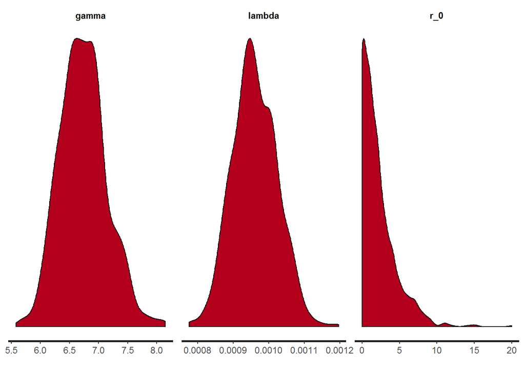

```r
stan_dens(fit)
```

```r
print(fit,digits = 4)
```

```
## Inference for Stan model: sir.
## 2 chains, each with iter=1000; warmup=500; thin=1;
## post-warmup draws per chain=500, total post-warmup draws=1000.
##
##              mean se_mean     sd       2.5%        25%        50%
## gamma      6.7349  0.0147 0.4047     6.0215     6.4563     6.7196
## lambda     0.0010  0.0000 0.0001     0.0008     0.0009     0.0010
## r_0        2.0260  0.0759 2.3140     0.0000     0.0000     1.0000
## lp__   -1698.3973  0.0488 1.0041 -1701.4818 -1698.7709 -1698.1042
##              75%      97.5% n_eff   Rhat
## gamma      6.977     7.5694   759 0.9997
## lambda     0.001     0.0011  1000 0.9987
## r_0        3.000     8.0000   929 1.0026
## lp__   -1697.665 -1697.4300   424 0.9981
##
## Samples were drawn using NUTS(diag_e) at Tue May 09 13:04:32 2017.
## For each parameter, n_eff is a crude measure of effective sample size,
## and Rhat is the potential scale reduction factor on split chains (at
## convergence, Rhat=1).
```

So, we see that the estimate of $\lambda$ is 0.0010, with 95% credible interval of (0.0008, 0.0011), encompasing the true value of 0.001. Likewise, the CI for $\gamma$ is (6,7.5), encolsing the true value of 7.

## SIR with Covariates

Making the model a little more complicated, lets assume that instead of a well-mixed population, there are children and adults in families. In the simulation below, the probability of getting infected from someone within a family is much higher than getting infected from someone in the community. In addition, the duration of shedding is much shorter for adults than for children.

Here, we use the probability model for infection:

$$Pr(j \in I_t \,|\,\, j \in S_{t-1},\, I_{t-1} ) = 1- (1- \lambda_F)^{|I^F_{t-1}|}(1- \lambda_C)^{|I^C_{t-1}|},$$
where $\lambda_F$ and $\lambda_C$ are transmission rates within families and the community, respectively, and $I^F_t$ and $I^C_t$ are the set of infected individuals in the family and community at time $t$, respectively. While I’m not using the large-sample approximation $(1- \lambda_F)^{|I^F_{t-1}|}(1- \lambda_C)^{|I^C_{t-1}|} \approx e^{-\lambda_F|I^F_{t-1}| - \lambda_C |I^C_{t-1}|}$, it makes the probability log-linear, and is conducive to adding other covariates as well.

Likewise, we also now include $\gamma_{adult}$ and $\gamma_{child}$, which are just as in the model above.

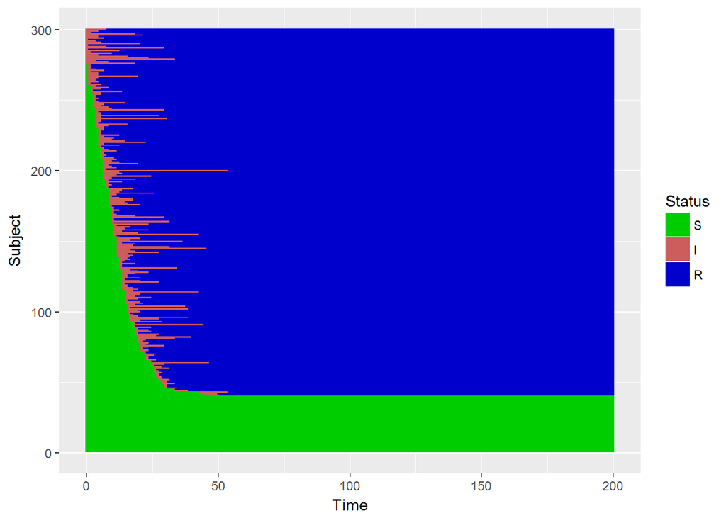

```r
set.seed(42)
N = 300 # number of subjects
t = 200 # number of time points
lambda_family = 0.1 # transmission probability (per person per 'close contact', per day)
lambda_community = 0.0005# transmission probability (per person per 'person in community', per day)
I0 = 25 # number of children initially infected

gamma_child = 10 # mean shedding duration for child (naive child)
gamma_adult = 3 # mean shedding duration for an adult (prior immunity)

fmat = bdiag(replicate(N/4,matrix(1,4,4),simplify = F)) #matrix indicating family membership
  diag(fmat) = 0
adult = rep(c(1,1,0,0),N/4) # two adults and two children per HH


data = expand.grid(subject = 1:N, time = 0:t) %>%
  tbl_df()

wdata = data %>% mutate(shedding = NA_character_) %>%
  spread(subject,shedding) %>% setNames(names(.) %>% make.names)


# keep track of immune and naive individuals
infected = c(rep(c(0,0,0,1),I0), rep(0,N-I0*4)) %>% as.numeric
susceptible = 1-infected
recovered = rep(0,N)

wdata[1,-1][susceptible ==1] = 'S'
wdata[1,-1][infected == 1] = 'I'
wdata[1,-1][recovered == 1] = 'R'

for(i in 1:t){
  #probability of infection = 1- probability of not getting infected, from either within HH, or within community
  #set to zero for those that aren't susceptible
  prob.infection = 1-((1-lambda_family)^(fmat%*%infected))*((1-lambda_community)^(sum(infected) - fmat%*%infected))
  prob.infection = as.numeric(prob.infection*susceptible)
  new.infection = rbinom(N,1,prob.infection)

  #probability of recovering 1= 1/gamma
  new.recovered = rbinom(N,1,adult*(1/gamma_adult) + (1-adult)*(1/gamma_child))
  new.recovered = new.recovered*infected

  #update SIR
  susceptible = if_else(new.infection==1,0,susceptible)
  recovered = if_else(new.recovered==1,1,recovered)

  infected = if_else(new.infection==1,1,infected)
  infected = if_else(new.recovered==1,0,infected)

  wdata[i+1,-1][susceptible ==1] = 'S'
  wdata[i+1,-1][infected == 1] = 'I'
  wdata[i+1,-1][recovered == 1] = 'R'
}

data = gather(wdata,subject,shedding, -time) %>% tbl_df()

data = data %>% group_by(subject) %>% mutate(start_shed = as.numeric(min(time[shedding == 'I']))) %>%
  ungroup %>%
  mutate(subject = reorder(subject,-start_shed), shedding = factor(shedding, levels = c('S','I','R'),ordered = T))

ggplot(data,aes(x=time,y=as.numeric(subject),fill = shedding)) +
  geom_tile() +
  scale_fill_manual('Status',values = c('S'='green3','I'='indianred','R'='blue3')) +
  ylab('Subject') + xlab('Time')
```

You can see here that the time of shedding is much more heterogeneous. Some individuals are infected for long periods, while others are infected for relatively short periods.

### Fitting the model in STAN:

Fitting the model is much the same in STAN, with the notable exception that we have to model individuals as independent non-identical bernoulli random variables, rather than collapsing them into a Binomial random variable.

```r
sircode_v2 = '
data {
  int<lower=0> N;
  int<lower=0> T;
  int<lower = 0,upper=1> S[T,N];
  int<lower = 0,upper=1> I[T,N];
  int<lower = 0,upper=1> R[T,N];
  matrix[N,N] fmat;
  int<lower=0,upper=1> adult[N];
  real<lower=0> lambda_max;
}
transformed data {
  int<lower=0, upper = 1> z_si[T-1,N];
  int<lower=0, upper = 1> z_ir[T-1,N];
  matrix[T,N] I_mat;
  matrix[T,N] fam_I;
  matrix[T,N] com_I;
  I_mat = to_matrix(I);
  fam_I = I_mat*fmat;

  for(t in 1:(T-1)){
    for(i in 1:N){
      z_si[t,i] = S[t,i] - S[t+1,i];
      z_ir[t,i] = R[t+1,i] - R[t,i];
      com_I[t,i] = sum(I_mat[t]) - I_mat[t]*fmat[,i];
    }
  }
}
parameters {
  real<lower=1> gamma_adult;
  real<lower=1> gamma_child;
  real<lower=0, upper = lambda_max> lambda_family;
  real<lower=0, upper = lambda_max> lambda_community;
}
model {
real prob_infection;

for(i in 1:N){
  for(t in 1:(T-1)){
    if( sum(I_mat[t]) > 0 && S[t,i]){
      prob_infection = 1- (  pow( 1-lambda_family, fam_I[t,i])*pow(1-lambda_community,com_I[t,i]));
      z_si[t,i] ~ bernoulli(prob_infection);
    }
    if(I[t,i]){
      if(adult[i]) z_ir[t,i] ~ bernoulli(1/gamma_adult);
      if(1-adult[i]) z_ir[t,i] ~ bernoulli(1/gamma_child);
    }
   }
}
}
'

#### fit model ############
mod_v2 = stan_model(model_name = 'sir_v2',model_code = sircode_v2)
```

[output not shown]

```r
stan_data = list(
  N = n,
  T = t+1,
  S = as.numeric(wdata[,-1] == 'S') %>% matrix(t+1,N),
  I = as.numeric(wdata[,-1] == 'I') %>% matrix(t+1,N),
  R = as.numeric(wdata[,-1] == 'R') %>% matrix(t+1,N),
  fmat = as.matrix(fmat),
  adult = adult,
  lambda_max = 1,
  dt = rep(1,t+1)
)

fit = sampling(mod_v2,stan_data, iter = 1000, chains = 1)
```

[output not shown]

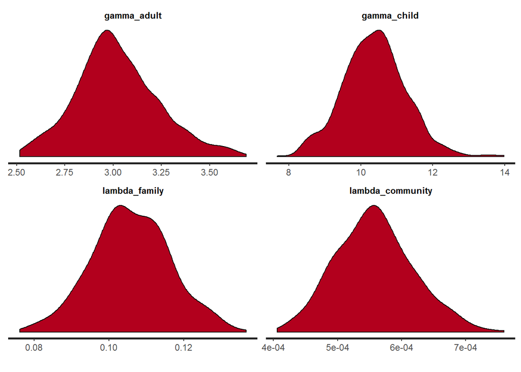

```r
stan_dens(fit)
```

```r
print(fit)
```

```
## Inference for Stan model: sir_v2.
## 1 chains, each with iter=1000; warmup=500; thin=1;
## post-warmup draws per chain=500, total post-warmup draws=500.
##
##                      mean se_mean   sd     2.5%      25%      50%      75%
## gamma_adult          3.02    0.01 0.21     2.62     2.89     3.00     3.14
## gamma_child         10.38    0.04 0.88     8.63     9.80    10.39    10.92
## lambda_family        0.11    0.00 0.01     0.09     0.10     0.11     0.11
## lambda_community     0.00    0.00 0.00     0.00     0.00     0.00     0.00
## lp__             -1480.46    0.10 1.50 -1484.07 -1481.21 -1480.09 -1479.33
##                     97.5% n_eff Rhat
## gamma_adult          3.52   500    1
## gamma_child         12.18   500    1
## lambda_family        0.13   500    1
## lambda_community     0.00   500    1
## lp__             -1478.65   207    1
##
## Samples were drawn using NUTS(diag_e) at Tue May 09 12:48:16 2017.
## For each parameter, n_eff is a crude measure of effective sample size,
## and Rhat is the potential scale reduction factor on split chains (at
## convergence, Rhat=1).
```

Again, we seem to recover the original parameters of the model. Here, I didn’t calculate $R_0$, but it is possible with slight modification of the simple SIR model. In defining $R_0$, note that we would expect different numbers of secondary infections depending on whether the index case is a child or an adult.

### SIR Model with variable time points:

This is straightforward for the transmission acquisition component of the model. For the transmission duration, we have to replace $1/\gamma$ by $1-(1-(1/\gamma))^{\Delta t}$.

Another wrinkle introduced is censoring: with multiple days between observations, we do not know precisely when people start and stop shedding. For now I’ll ignore this, and assess what bias might be introduced through this simulation. As we will see, in the current simulation, it appears that the bias is small relative to statistical uncertainty in the parameters.

```r
sircode_v3 = '
data {
  int<lower=0> N;
  int<lower=0> T;
  int<lower = 0,upper=1> S[T,N];
  int<lower = 0,upper=1> I[T,N];
  int<lower = 0,upper=1> R[T,N];
  matrix[N,N] fmat;
  int<lower=0,upper=1> adult[N];
  real<lower=0> lambda_max;
  real<lower=0> dt[T];
}
transformed data {
  int<lower=0, upper = 1> z_si[T-1,N];
  int<lower=0, upper = 1> z_ir[T-1,N];
  matrix[T,N] I_mat;
  matrix[T,N] fam_I;
  matrix[T,N] com_I;
  I_mat = to_matrix(I);
  fam_I = I_mat*fmat;

  for(t in 1:(T-1)){
    for(i in 1:N){
      z_si[t,i] = S[t,i] - S[t+1,i];
      z_ir[t,i] = R[t+1,i] - R[t,i];
      com_I[t,i] = sum(I_mat[t]) - I_mat[t]*fmat[,i];
    }
  }
}
parameters {
  real<lower=1> gamma_adult;
  real<lower=1> gamma_child;
  real<lower=0, upper = lambda_max> lambda_family;
  real<lower=0, upper = lambda_max> lambda_community;
}
model {
real prob_infection;

for(i in 1:N){
  for(t in 1:(T-1)){
    if( sum(I_mat[t]) > 0 && S[t,i]){
      prob_infection = 1- (  pow( 1-lambda_family*dt[t], fam_I[t,i])*pow(1-lambda_community*dt[t],com_I[t,i]));
      z_si[t,i] ~ bernoulli(prob_infection);
    }
    if(I[t,i]){
      if(adult[i]) z_ir[t,i] ~ bernoulli( 1-(1-(1/gamma_adult))^dt[t] );
      if(1-adult[i]) z_ir[t,i] ~ bernoulli( 1- (1-(1/gamma_child))^dt[t] );
    }
   }
}
}
'

#### fit model ############
mod_v3 = stan_model(model_name = 'sir_v3',model_code = sircode_v3)
```

[output not shown]

```r
time.pts = c(1,3, 6, 10)


stan_data = list(
  N = n,
  T = length(time.pts),
  S = as.numeric(wdata[time.pts,-1] == 'S') %>% matrix(length(time.pts),N),
  I = as.numeric(wdata[time.pts,-1] == 'I') %>% matrix(length(time.pts),N),
  R = as.numeric(wdata[time.pts,-1] == 'R') %>% matrix(length(time.pts),N),
  fmat = as.matrix(fmat),
  adult = adult,
  lambda_max = 1,
  dt = c(diff(time.pts),0)
)


fit = sampling(mod_v3,stan_data, iter = 1000, chains = 1, seed =3)
```

[output not shown]

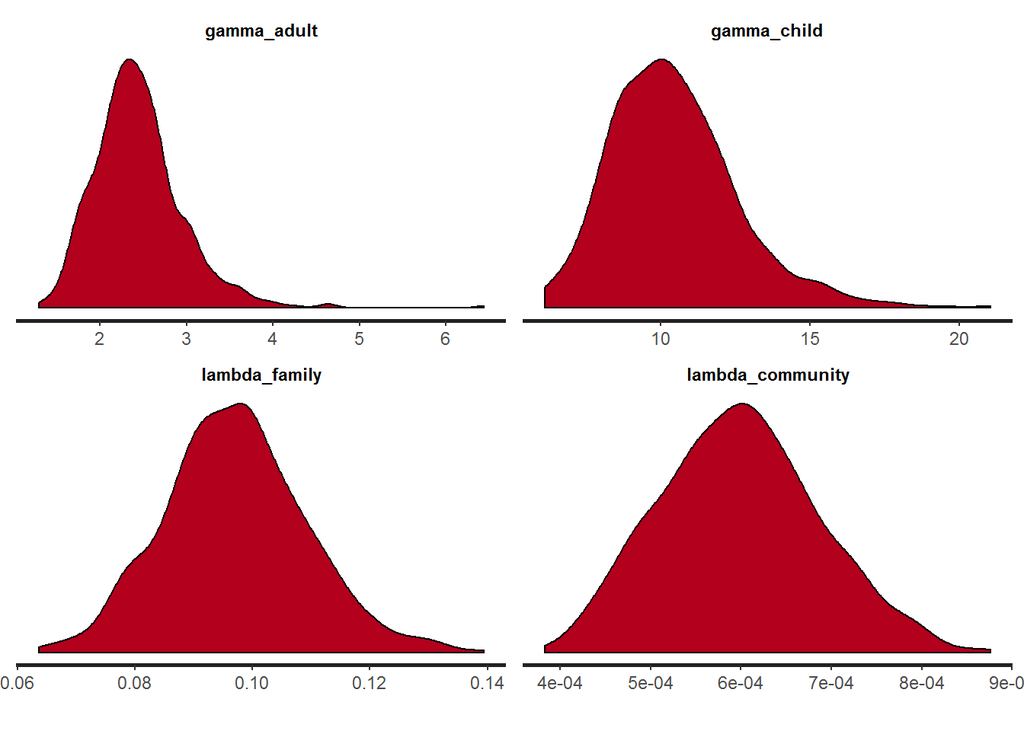

```r
stan_dens(fit)
```

```r
print(fit)
```

```
## Inference for Stan model: sir_v3.
## 1 chains, each with iter=1000; warmup=500; thin=1;
## post-warmup draws per chain=500, total post-warmup draws=500.
##
##                     mean se_mean   sd    2.5%     25%     50%     75%
## gamma_adult         2.44    0.02 0.53    1.65    2.12    2.39    2.69
## gamma_child        10.46    0.10 2.16    7.01    8.91   10.23   11.65
## lambda_family       0.10    0.00 0.01    0.08    0.09    0.10    0.10
## lambda_community    0.00    0.00 0.00    0.00    0.00    0.00    0.00
## lp__             -311.47    0.11 1.57 -315.17 -312.25 -311.08 -310.32
##                    97.5% n_eff Rhat
## gamma_adult         3.62   500 1.00
## gamma_child        15.45   500 1.00
## lambda_family       0.12   500 1.00
## lambda_community    0.00   500 1.01
## lp__             -309.64   220 1.02
##
## Samples were drawn using NUTS(diag_e) at Tue May 09 13:05:34 2017.
## For each parameter, n_eff is a crude measure of effective sample size,
## and Rhat is the potential scale reduction factor on split chains (at
## convergence, Rhat=1).
```

Again, the posterior distribution provides good support for the true parameters.

It is interesting that with only 4 points of observation, the posterior variability is larger, but of a comparable magnitude, to that based on the estimates with 200 points of observation.

[interactive chart not shown]